# Part C. Querying the World Bank API

Load all packages here:

```r
suppressMessages(library('tidyverse'))
suppressMessages(library('httr'))
suppressMessages(library('jsonlite'))
suppressMessages(library('dplyr'))
suppressMessages(library('countrycode'))
suppressMessages(library('stargazer'))
```

1. The goal of this part of the assignment is to obtain country-level development indicators that may be related to linguistic fragmentation from the World Bank API. You can read the documentation and instructions [here](https://datahelpdesk.worldbank.org/knowledgebase/articles/898581-basic-api-call-structures).

Write your own function that will take an indicator code (e.g. `SP.POP.TOTL`) as input, query the API, parse the JSON output into R, and then return a clean data frame where each row is a country. If you’re not able to figure it out, you can also use the `WDI` package. Feel free to take a look at the code for some clues on how to query the API (see e.g. [here](https://github.com/vincentarelbundock/WDI/blob/master/R/WDI.R)). (15 points)

*indicator_function is created, which enables the user to type in an indicator code in the subsequent ‘update_url’ feature. This will update the relevant part of ‘url’ with the indicator code (SP.POP.TOTL is used here as an example). In this example, the url will take all country/region data (264) in 2019 from the World Bank website.*

*The API is queried and the JSON output is parsed into R with fromJSON(). The output is stored in a tibble data frame called ‘country_population’, which is then cleaned. Notably, three empty columns are removed, and ‘countryiso3code’ column is renamed to ‘country.code’. Countries with NA indicator values are omitted. A sample of the data is then printed using tail(). Pipe operators (%>%) facilitate this.*

```r
indicator_function <- function(indicator_id) {
  #' Function runs over the API link and replaces indicator_id with relevant input from update_url
  url <- sprintf(paste0("http://api.worldbank.org/v2/country/all/indicator/", indicator_id, "?format=json&per_page=264&date=2019"))
}

# Update url with an indicator code, e.g. NY.GDP.PCAP.KD if GDP per capita indicator is of interest:
update_url <- indicator_function('SP.POP.TOTL') # Population indicator_id

# Takes URL from WB API, parses into R, converts to tibble, reformats, omits NA's
country_population <- fromJSON(update_url) %>%
  pluck(2) %>%
  as_tibble() %>%
  rename(country.code = countryiso3code) %>%
  select(-unit, -obs_status, -decimal) %>%
  na.omit

# Display dataframe
tail(do.call(data.frame, country_population))
```

```
##     indicator.id   indicator.value country.id         country.value
## 257  SP.POP.TOTL Population, total         VN               Vietnam
## 258  SP.POP.TOTL Population, total         VI Virgin Islands (U.S.)
## 259  SP.POP.TOTL Population, total         PS    West Bank and Gaza
## 260  SP.POP.TOTL Population, total         YE           Yemen, Rep.
## 261  SP.POP.TOTL Population, total         ZM                Zambia
## 262  SP.POP.TOTL Population, total         ZW              Zimbabwe
##     country.code date    value
## 257          VNM 2019 96462106
## 258          VIR 2019   106631
## 259          PSE 2019  4685306
## 260          YEM 2019 29161922
## 261          ZMB 2019 17861030
## 262          ZWE 2019 14645468
```

2. Using the function you just created, get country-level data on two metrics: GDP per capita and another metric that you consider could be correlated with language fractionalization (see the Alesina et al paper for inspiration). (5 points)

*Country-level data on GDP per capita (indicator code: NY.GDP.PCAP.CD) and received remittances (indicator code: BX.TRF.PWKR.CD.DT) is achieved by using the indicator_function defined in question 1. The data is retrieved and stored in two tibbles (‘country_GDP’ and ‘country_remittances’ respectively) using similar methodology to question 1 (i.e. the same cleaning process takes place). Snippets of the tibbles are printed with tail().*

*indicator_vec represents a vector of the two indicator codes which allows the lapply function to be applied. This means that the code does not need to be repeated and instead it will loop through the indicator ids in indicator_vec to create tibbles for each indicator.*

*Remittances are transfers from one country to another, usually by international workers to individuals in their country of origin. This could be correlated with language fractionalization if countries with multiple national languages (e.g. Switzerland) attract workers with those language skills from a wider pool of countries (e.g. German, French and Italian speaking countries), who could then send money back to their home countries.*

```r
indicator_vec <- c('NY.GDP.PCAP.CD', 'BX.TRF.PWKR.CD.DT')

indicator_list <- lapply(indicator_vec, function(x) {
  #' Takes vector of URL's from WB API, parses into R, converts to tibble, reformats, omits NA's
  update_url <- indicator_function(x)
  fromJSON(update_url) %>%
  pluck(2) %>%
  as_tibble() %>%
  rename(country.code = countryiso3code) %>%
  select(-unit, -obs_status, -decimal) %>%
  na.omit
})

# Extract two tibbles from lists in "indicator_lists
country_GDP <- indicator_list[[1]]
country_remittances <- indicator_list[[2]]

# Display both dataframes
tail(do.call(data.frame, country_GDP))
```

```
##       indicator.id              indicator.value country.id country.value
## 218 NY.GDP.PCAP.CD GDP per capita (current US$)         UY       Uruguay
## 219 NY.GDP.PCAP.CD GDP per capita (current US$)         UZ    Uzbekistan
## 220 NY.GDP.PCAP.CD GDP per capita (current US$)         VU       Vanuatu
## 221 NY.GDP.PCAP.CD GDP per capita (current US$)         VN       Vietnam
## 222 NY.GDP.PCAP.CD GDP per capita (current US$)         ZM        Zambia
## 223 NY.GDP.PCAP.CD GDP per capita (current US$)         ZW      Zimbabwe
##     country.code date     value
## 218          URY 2019 16190.127
## 219          UZB 2019  1724.841
## 220          VUT 2019  3058.066
## 221          VNM 2019  2715.276
## 222          ZMB 2019  1291.343
## 223          ZWE 2019  1463.986
```

```r
tail(do.call(data.frame, country_remittances))
```

```
##          indicator.id                              indicator.value country.id
## 227 BX.TRF.PWKR.CD.DT Personal remittances, received (current US$)         VE
## 228 BX.TRF.PWKR.CD.DT Personal remittances, received (current US$)         VN
## 229 BX.TRF.PWKR.CD.DT Personal remittances, received (current US$)         PS
## 230 BX.TRF.PWKR.CD.DT Personal remittances, received (current US$)         YE
## 231 BX.TRF.PWKR.CD.DT Personal remittances, received (current US$)         ZM
## 232 BX.TRF.PWKR.CD.DT Personal remittances, received (current US$)         ZW
##          country.value country.code date       value
## 227      Venezuela, RB          VEN 2019   279000000
## 228            Vietnam          VNM 2019 17000000000
## 229 West Bank and Gaza          PSE 2019  2860918604
## 230        Yemen, Rep.          YEM 2019  3770584064
## 231             Zambia          ZMB 2019    98259100
## 232           Zimbabwe          ZWE 2019  1729883840
```

3. Merge this new country-level dataset with the dataset `part_b_fractionalization_output.csv` that you created at the end of part B. As before, you may need to fix some of the country names to ensure that all countries can be merged. (10 points)

*wb_data_gdp_remittances dataframe is created by combining (by country code) the country_GDP and country_remittances tibbles defined earlier.*

*The country spellings are then standardised within the country_code_vector, which is used to update the relevant country name column within wb_data_gdp_remittances.*

```r
# Merge the World Bank datasets
wb_data_gdp_remittances <- merge(country_GDP, country_remittances, by = 'country.code')

# Homogenize country spellings of countries from World Bank dataset and fractionalization_index. The warning below indicate regions which through not matching each customly, are deliberately dropped.
country_code_vector <- countrycode(wb_data_gdp_remittances$country.code, origin = 'iso3c', destination = 'country.name')
wb_data_gdp_remittances$country_name <- country_code_vector

# Omit NA's and rename ambiguous columns
wb_data_gdp_remittances_updated <- wb_data_gdp_remittances %>%
  na.omit %>%
  rename(GDP_per_capita = value.x,
         remittances_USD = value.y)
head(wb_data_gdp_remittances_updated)
```

```
##    country.code indicator.x.id            indicator.x.value country.x.id
## 17          AFG NY.GDP.PCAP.CD GDP per capita (current US$)           AF
## 18          AGO NY.GDP.PCAP.CD GDP per capita (current US$)           AO
## 19          ALB NY.GDP.PCAP.CD GDP per capita (current US$)           AL
## 21          ARG NY.GDP.PCAP.CD GDP per capita (current US$)           AR
## 22          ARM NY.GDP.PCAP.CD GDP per capita (current US$)           AM
## 23          ATG NY.GDP.PCAP.CD GDP per capita (current US$)           AG
##        country.x.value date.x GDP_per_capita    indicator.y.id
## 17         Afghanistan   2019       502.1155 BX.TRF.PWKR.CD.DT
## 18              Angola   2019      2973.5912 BX.TRF.PWKR.CD.DT
## 19             Albania   2019      5352.8574 BX.TRF.PWKR.CD.DT
## 21           Argentina   2019     10006.1490 BX.TRF.PWKR.CD.DT
## 22             Armenia   2019      4622.7335 BX.TRF.PWKR.CD.DT
## 23 Antigua and Barbuda   2019     17790.3093 BX.TRF.PWKR.CD.DT
##                               indicator.y.value country.y.id
## 17 Personal remittances, received (current US$)           AF
## 18 Personal remittances, received (current US$)           AO
## 19 Personal remittances, received (current US$)           AL
## 21 Personal remittances, received (current US$)           AR
## 22 Personal remittances, received (current US$)           AM
## 23 Personal remittances, received (current US$)           AG
##        country.y.value date.y remittances_USD      country_name
## 17         Afghanistan   2019       828571904       Afghanistan
## 18              Angola   2019         3445473            Angola
## 19             Albania   2019      1472812242           Albania
## 21           Argentina   2019       528289414         Argentina
## 22             Armenia   2019      1527961727           Armenia
## 23 Antigua and Barbuda   2019        24706009 Antigua & Barbuda
```

```r
# Merge wb_data_gdp_rural and fractionalization_index
part_b_fractionalization_output <- read.csv("part_b_fractionalization_output.csv")

# Merge both datasets and reorder and simplify columns
merged_wb_group11 <- merge(wb_data_gdp_remittances_updated, part_b_fractionalization_output) %>%
  select(country_name, country_code, tweets_collected, language_fractionalization_index_tweets, language_fractionalization_index_alesina_et_al., GDP_per_capita, remittances_USD)

# In order to make this dataframe easier to read, we compress two variables names (LF = language fractionalization)
merged_wb_group11 <- merged_wb_group11 %>%
  rename(LF_tweets = language_fractionalization_index_tweets,
         LF_alesina = language_fractionalization_index_alesina_et_al.)

# Head merged dataframe
head(merged_wb_group11)
```

```
##           country_name country_code tweets_collected LF_tweets LF_alesina
## 1              Albania           AL              142 0.8276136     0.0399
## 2              Algeria           DZ              442 0.6495158     0.4427
## 3              Austria           AT              926 0.7298840     0.1522
## 4              Belarus           BY              406 0.1930040     0.4666
## 5              Belgium           BE             2111 0.7963704     0.5409
## 6 Bosnia & Herzegovina           BA              140 0.5384694     0.6751
##   GDP_per_capita remittances_USD
## 1       5352.857      1472812242
## 2       3948.343      1792000000
## 3      50277.275      3045303722
## 4       6663.295      1418800000
## 5      46116.699     12156775770
## 6       6073.265      2261210856
```

4. What can you learn about the relationship between language fractionalization and economic development from this new dataset? Can you replicate some of the findings in Tables 5 and 8 of the paper? With the index from the paper? With your Twitter index? Use any statistical or graphical analyses that you consider appropriate to answer this question. A word of caution when interpreting these results: We can form hypotheses based on such findings, but only from the fact that two or more variables co-move/correlate, we cannot say whether they cause each other to move or not [link](https://en.wikipedia.org/wiki/Correlation_does_not_imply_causation). (10 points)

*The findings of Alesina et al. (2003) deviate strongly from what our analysis of the relationship between GDP per capita and language fractionalization found. Whereas, Alesina et al. postulated a negative relationship between the two variables in their paper (and we were able to reproduce this result in a simple and uncontrolled linear regression), our analysis with Twitter-data found the opposite relationship, which was in fact more positive than the relationship between the data from Alesina et al. (2003) was negative. Although this finding appears striking at first sight, this indicates little more than a necessity for more research into this relationship, isolating the effect of the primary independent variable (language fractionalization) onto GDP per capita.*

```r
# Create correlation matrix
correlation.matrix <- cor(merged_wb_group11[4:7], use = "all.obs", method = c("pearson"))
stargazer(correlation.matrix, type = 'html')
```

|  | LF_tweets | LF_alesina | GDP_per_capita | remittances_USD |
| --- | --- | --- | --- | --- |
| LF_tweets | 1 | 0.189 | 0.129 | -0.045 |
| LF_alesina | 0.189 | 1 | -0.042 | -0.030 |
| GDP_per_capita | 0.129 | -0.042 | 1 | -0.042 |
| remittances_USD | -0.045 | -0.030 | -0.042 | 1 |

```r
# Create regression table
linear_model_tweets <- lm(GDP_per_capita ~ LF_tweets, data=merged_wb_group11)
linear_model_alesina <- lm(GDP_per_capita ~ LF_alesina, data=merged_wb_group11)
stargazer(linear_model_tweets, linear_model_alesina, type = 'html')
```

|  | *Dependent variable:* |  |
| --- | --- | --- |
|  | GDP_per_capita |  |
|  | (1) | (2) |
| LF_tweets | 20,037.620 |  |
|  | (24,727.410) |  |
| LF_alesina |  | -5,301.405 |
|  |  | (20,363.940) |
| Constant | 18,298.530 | 31,973.060*** |
|  | (15,677.470) | (6,841.577) |
| Observations | 41 | 41 |
| R<sup>2</sup> | 0.017 | 0.002 |
| Adjusted R<sup>2</sup> | -0.009 | -0.024 |
| Residual Std. Error (df = 39) | 26,363.100 | 26,561.050 |
| F Statistic (df = 1; 39) | 0.657 | 0.068 |
| *Note:* | p<0.1; p<0.05; p<0.01 |  |

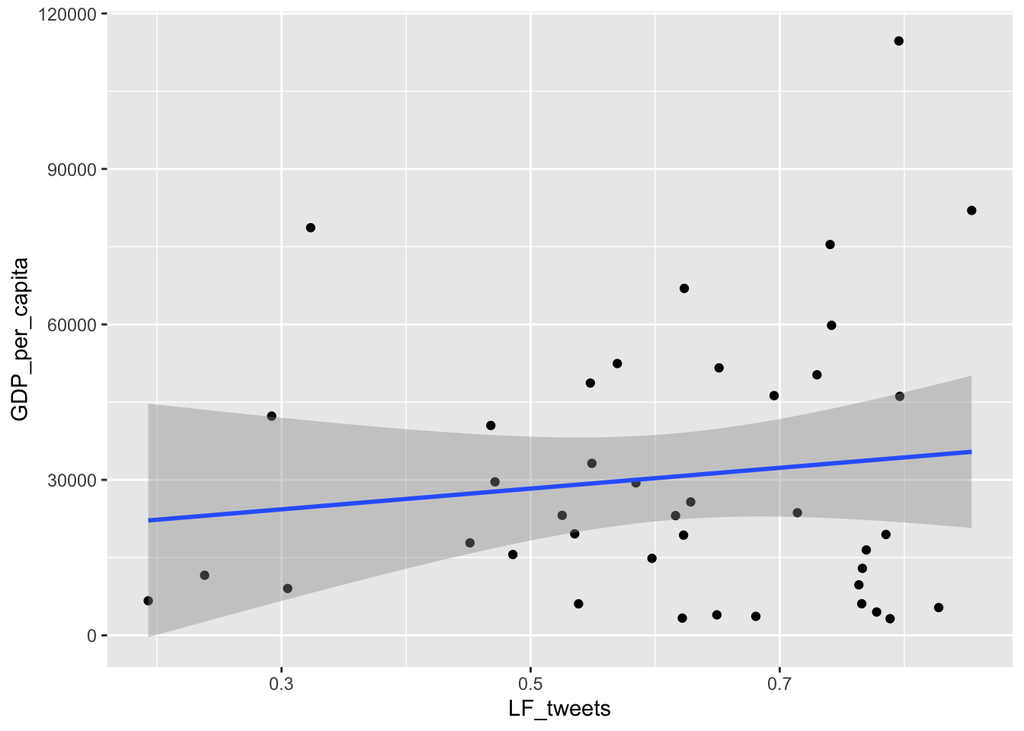

```r
# For visual analysis, create two scatter plots (LF_alesina x GDP_per_capita & LF_tweets x GDP_per_capita)
#1
ggplot(merged_wb_group11, aes(x=LF_tweets, y=GDP_per_capita)) +
  geom_point() +
  geom_smooth(method=lm)
```

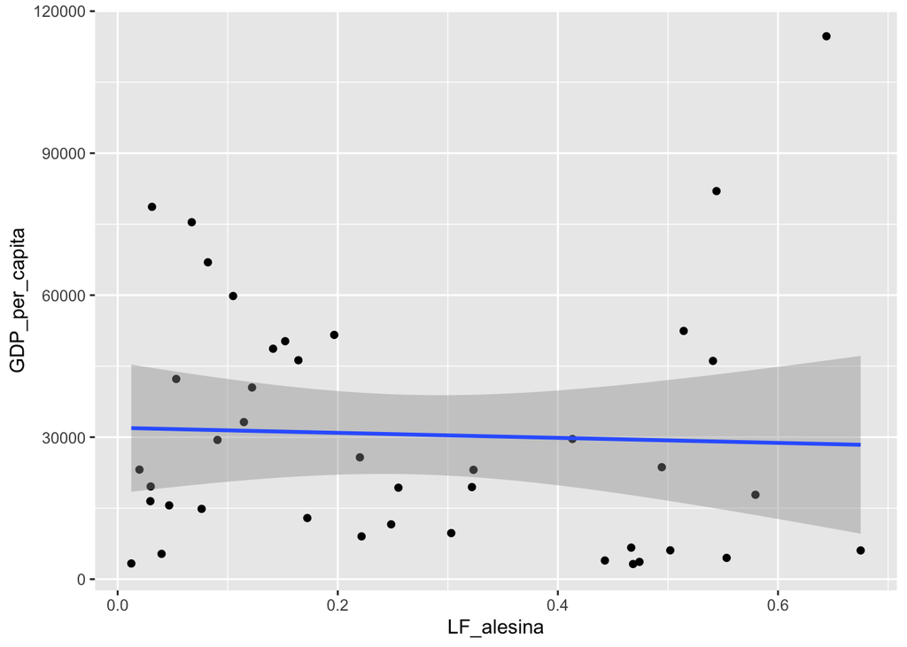

```r
#2
ggplot(merged_wb_group11, aes(x=LF_alesina, y=GDP_per_capita)) +
  geom_point() +
  geom_smooth(method=lm)
```